# Loan data analysis of the Irish dummy bank

## By: Mohammed Modather Taha

## Preview:

### 1- This dataset provides detailed information for the loans lent by the irish dummy bank in which it provides funds for potential borrowers and earn a profit depending on their obligation.

### 2- The information provided in dataset show the bank's loan data from year 2007 to 2015

## Features:

### 3- interest_rate: interest rate is the amount a lender charges a borrower and is a percentage of the amount loaned.

### 4- term: The number of payments on the loan. Values are in months and can be either 36 or 60

### 5- loan_amount:The amount of fund provided for the borrower in loan application

### 6- purpose: The reason supplied by the borrower in the application for why he needs the money

### 7- emp_length_time: Employment length in years. Possible values are between 0 and 10 where 0 means less than one year and 10 means ten or more years.

### 8- region: The state provided by the borrower in the loan application

### 9- installment: The monthly payment owed by the borrower if the loan originates.

### 10- application_type: Indicates whether the loan is an individual application or a joint application with two co-borrowers

### 11- dti: A ratio calculated using the borrower’s total monthly debt payments on the total debt obligations, - - - excluding mortgage and the requested LC loan, divided by the borrower’s self-reported monthly income.

|  | id | year | emp_length_int | annual_inc | loan_amount | term_month | interest_rate | dti | installment | net_income | interest+loan_amn |
| --- | --- | --- | --- | --- | --- | --- | --- | --- | --- | --- | --- |
| count | 1.016900e+05 | 101690.000000 | 101690.000000 | 101690.000000 | 101690.000000 | 101690.000000 | 101690.000000 | 101690.000000 | 101690.000000 | 101690.000000 | 101690.000000 |
| mean | 3.246982e+07 | 2014.020110 | 6.056598 | 67605.437624 | 14342.071738 | 43.179467 | 13.271921 | 18.396648 | 424.280101 | 412.027238 | 18736.626267 |
| std | 2.283575e+07 | 1.265919 | 3.500273 | 29907.381303 | 8179.244528 | 10.989252 | 4.363554 | 8.295418 | 234.972959 | 1190.729204 | 11784.674349 |
| min | 5.552100e+04 | 2007.000000 | 0.500000 | 4000.000000 | 500.000000 | 36.000000 | 5.320000 | 0.000000 | 16.250000 | 0.000000 | 585.000000 |
| 25% | 9.206610e+06 | 2013.000000 | 3.000000 | 45000.000000 | 8000.000000 | 36.000000 | 9.990000 | 12.180000 | 255.300000 | 0.000000 | 9642.240000 |
| 50% | 3.445367e+07 | 2014.000000 | 6.050000 | 62000.000000 | 12375.000000 | 36.000000 | 12.990000 | 17.980000 | 374.150000 | 0.000000 | 16435.440000 |
| 75% | 5.506960e+07 | 2015.000000 | 10.000000 | 85000.000000 | 20000.000000 | 60.000000 | 16.240000 | 24.220000 | 553.160000 | 0.000000 | 25174.800000 |
| max | 6.861687e+07 | 2015.000000 | 10.000000 | 156620.000000 | 35000.000000 | 60.000000 | 28.990000 | 42.030000 | 1408.130000 | 21087.909920 | 66007.800000 |

### 1- These are plots that show the value counts of loan status feature and explain its correlation with other features like year, region, purpose, home ownership and interest rate.

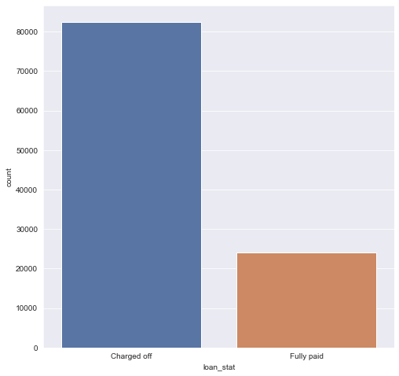

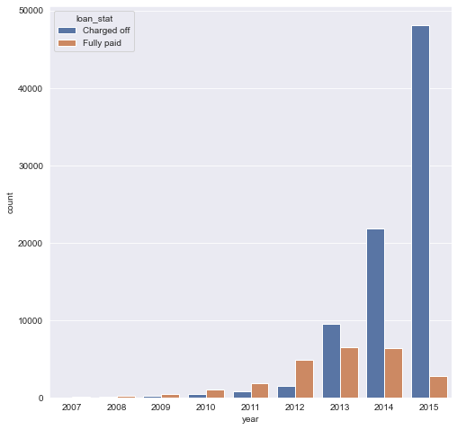

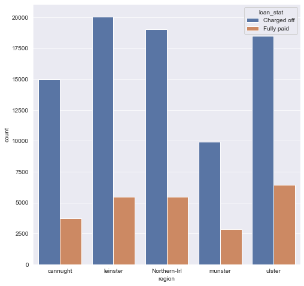

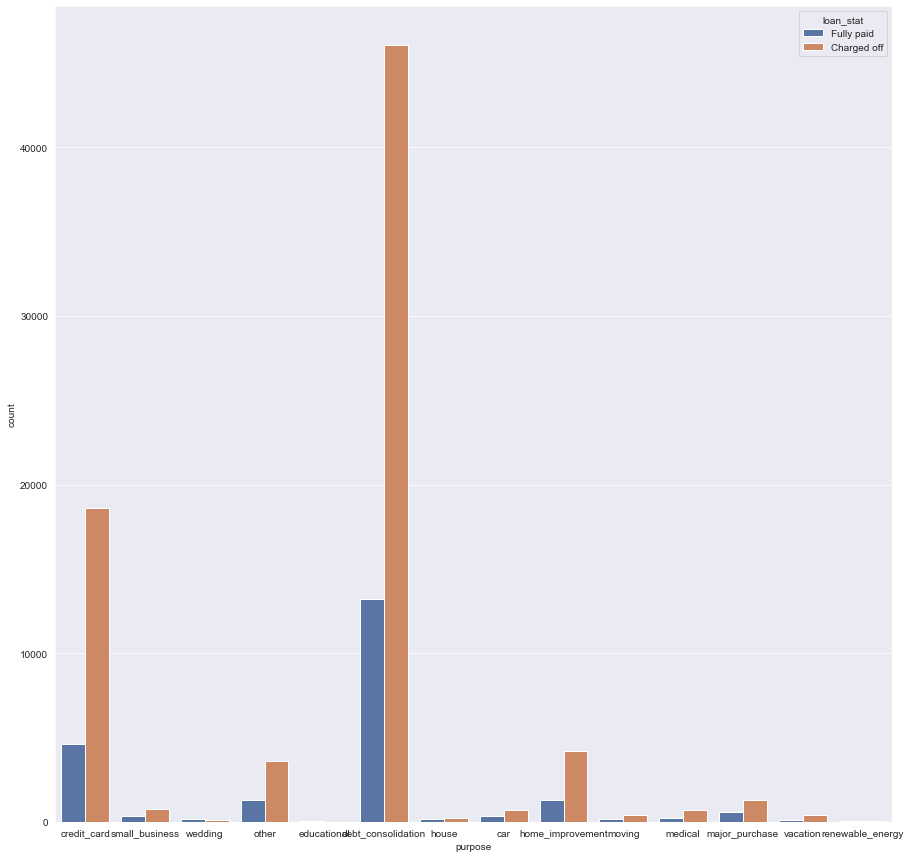

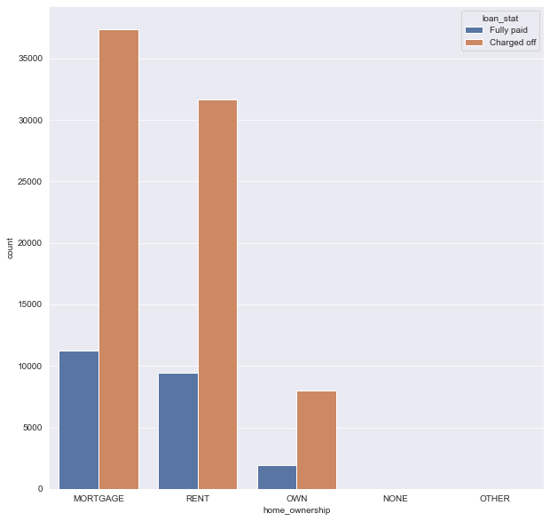

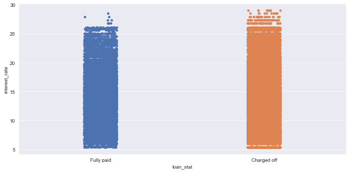

### 2- A plot which shows the correlation between net income and home ownership features over years

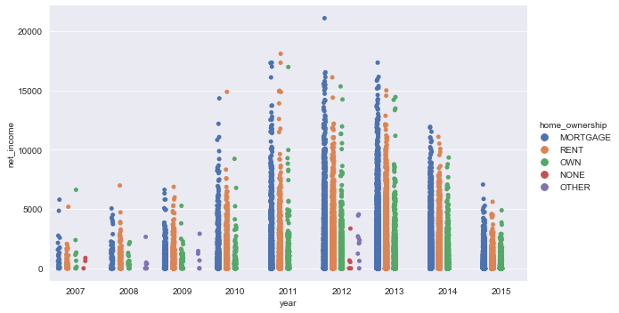

### 3- A plot which shows correlation between annual income and home ownership features and its effect on the value counts of loan status

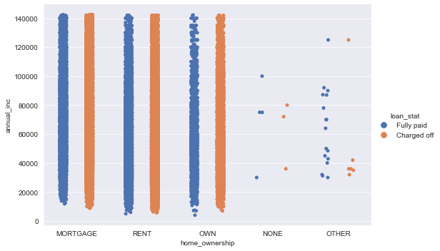

### 4- A plot which shows the correlation between home ownership and loan amount features and their effect on the value counts of loan status

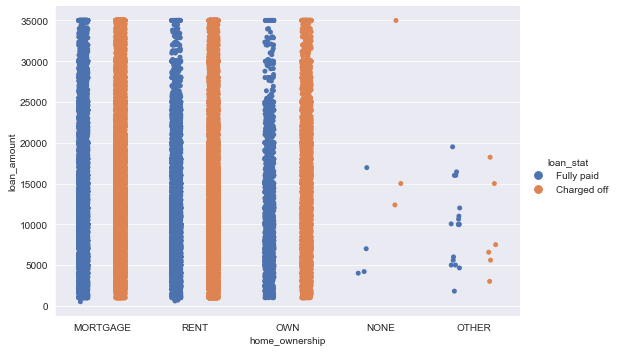

### 5- A plot which shows the correlation between region and loan amount features and their effect on the value counts of loan status

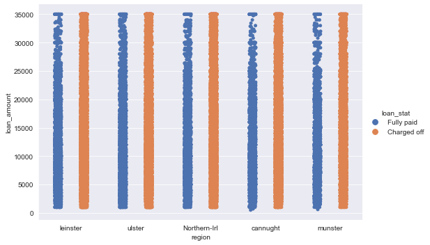

### 6- A plot which shows the correlation coefficient between the numeric features

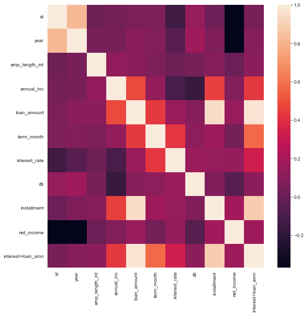

## Recommendations:

### 1- Decrease the total number of loans lent annually as in 2012 and 2013 so that the bank can assess the loan applications wisely

### 2- Support the loan applicants with wedding and educational purposes with lower interest rate to gain more clients

### 3- The bank should accept individual applications only